# Class-Survival Gap Analysis: Access vs. Policy on the Titanic

Author

CLI Copilot

# Introduction

## Research Question

To what extent is the survival advantage of 1st class passengers mediated by *location/access* (deck/cabin proximity, cabin availability, fare level) versus *policy* (“women and children first”)? This analysis proposes a methodological framework to quantify these mechanisms using mediation analysis concepts.

## Why This Matters

The Titanic dataset presents a unique natural experiment. Class survival disparities could stem from two distinct mechanisms: (1) **structural access** — first-class passengers had better access to lifeboats due to their cabin locations and the ship’s design, and (2) **social policy** — the “women and children first” evacuation protocol may have been applied differentially across classes. By decomposing the class effect into direct effects (policy) and indirect effects (access), we can understand whether class mattered because of *where* people were located or *who* was prioritized.

## Data Overview

The analysis uses the Titanic passenger dataset with 891 passengers in the training set. Variables include passenger class (Pclass), demographics (Sex, Age), family relationships (SibSp, Parch), cabin information (Cabin), fare paid (Fare), embarkation port (Embarked), and survival outcome (Survived).

# Data Preparation and Exploration

## Loading and Inspecting the Data

```r
library(tidyverse)
library(knitr)

# Load data
titanic_raw <- read_csv('../../data/train.csv', show_col_types = FALSE)

# Display structure
tibble::glimpse(titanic_raw)
```

```
Rows: 891
Columns: 12
$ PassengerId <dbl> 1, 2, 3, 4, 5, 6, 7, 8, 9, 10, 11, 12, 13, 14, 15, 16, 17,…
$ Survived    <dbl> 0, 1, 1, 1, 0, 0, 0, 0, 1, 1, 1, 1, 0, 0, 0, 1, 0, 1, 0, 1…
$ Pclass      <dbl> 3, 1, 3, 1, 3, 3, 1, 3, 3, 2, 3, 1, 3, 3, 3, 2, 3, 2, 3, 3…
$ Name        <chr> "Braund, Mr. Owen Harris", "Cumings, Mrs. John Bradley (Fl…
$ Sex         <chr> "male", "female", "female", "female", "male", "male", "mal…
$ Age         <dbl> 22, 38, 26, 35, 35, NA, 54, 2, 27, 14, 4, 58, 20, 39, 14, …
$ SibSp       <dbl> 1, 1, 0, 1, 0, 0, 0, 3, 0, 1, 1, 0, 0, 1, 0, 0, 4, 0, 1, 0…
$ Parch       <dbl> 0, 0, 0, 0, 0, 0, 0, 1, 2, 0, 1, 0, 0, 5, 0, 0, 1, 0, 0, 0…
$ Ticket      <chr> "A/5 21171", "PC 17599", "STON/O2. 3101282", "113803", "37…
$ Fare        <dbl> 7.2500, 71.2833, 7.9250, 53.1000, 8.0500, 8.4583, 51.8625,…
$ Cabin       <chr> NA, "C85", NA, "C123", NA, NA, "E46", NA, NA, NA, "G6", "C…
$ Embarked    <chr> "S", "C", "S", "S", "S", "Q", "S", "S", "S", "C", "S", "S"…
```

This code chunk loads the training dataset and displays its structure. We use `tidyverse` for data manipulation and ggplot2 for visualization. The glimpse function provides column names, data types, and sample values, allowing us to understand the dataset’s composition before analysis.

```r
# Check dimensions and missing values
cat("Dataset dimensions:", nrow(titanic_raw), "rows x", ncol(titanic_raw), "columns\n\n")
```

```
Dataset dimensions: 891 rows x 12 columns
```

```r
missing_summary <- titanic_raw %>%
  summarise(across(everything(), ~sum(is.na(.)))) %>%
  pivot_longer(everything(), names_to = "Variable", values_to = "Missing_Count") %>%
  mutate(Missing_Percent = round(100 * Missing_Count / nrow(titanic_raw), 1)) %>%
  arrange(desc(Missing_Count))

kable(missing_summary, caption = "Missing Values Summary")
```

Missing Values Summary

| Variable | Missing_Count | Missing_Percent |
| --- | --- | --- |
| Cabin | 687 | 77.1 |
| Age | 177 | 19.9 |
| Embarked | 2 | 0.2 |
| PassengerId | 0 | 0.0 |
| Survived | 0 | 0.0 |
| Pclass | 0 | 0.0 |
| Name | 0 | 0.0 |
| Sex | 0 | 0.0 |
| SibSp | 0 | 0.0 |
| Parch | 0 | 0.0 |
| Ticket | 0 | 0.0 |
| Fare | 0 | 0.0 |

This chunk calculates missing value patterns across all variables. Understanding missingness is critical because (1) cabin data will be our key proxy for access/location, and (2) age missingness may bias survival estimates if not handled carefully. The table shows that Cabin has the most missing values (~77%), followed by Age (~20%), which will influence our proxy creation strategy.

## Creating Access and Demographic Proxies

```r
titanic <- titanic_raw %>%
  # Create cabin letter (deck proxy)
  mutate(
    cabin_letter = str_extract(Cabin, "^[A-Z]"),
    cabin_missing = is.na(Cabin),
    deck_known = !cabin_missing
  ) %>%
  # Create family size proxy for access constraints
  mutate(
    family_size = SibSp + Parch + 1,  # +1 for self
    family_group = case_when(
      family_size == 1 ~ "Alone",
      family_size == 2 ~ "Pair",
      family_size >= 3 ~ "Group3+"
    )
  ) %>%
  # Clean embarked (remove blanks)
  filter(Embarked != "" | is.na(Embarked)) %>%
  # Create class labels for clarity
  mutate(
    pclass_label = case_when(
      Pclass == 1 ~ "1st Class",
      Pclass == 2 ~ "2nd Class",
      Pclass == 3 ~ "3rd Class"
    ),
    sex_label = case_when(
      Sex == "male" ~ "Male",
      Sex == "female" ~ "Female"
    ),
    survived_label = case_when(
      Survived == 1 ~ "Survived",
      Survived == 0 ~ "Did Not Survive"
    )
  ) %>%
  # Convert to factors for analysis
  mutate(across(c(pclass_label, sex_label, survived_label, family_group), as.factor))

# Display processed data
cat("Processed dataset dimensions:", nrow(titanic), "rows x", ncol(titanic), "columns\n")
```

```
Processed dataset dimensions: 891 rows x 20 columns
```

```r
kable(head(titanic[, c("Pclass", "Sex", "Age", "Fare", "Cabin", "cabin_letter", "cabin_missing", "family_size", "Survived")], 10),
      caption = "Sample of Processed Data with Proxies")
```

Sample of Processed Data with Proxies

| Pclass | Sex | Age | Fare | Cabin | cabin_letter | cabin_missing | family_size | Survived |
| --- | --- | --- | --- | --- | --- | --- | --- | --- |
| 3 | male | 22 | 7.2500 | NA | NA | TRUE | 2 | 0 |
| 1 | female | 38 | 71.2833 | C85 | C | FALSE | 2 | 1 |
| 3 | female | 26 | 7.9250 | NA | NA | TRUE | 1 | 1 |
| 1 | female | 35 | 53.1000 | C123 | C | FALSE | 2 | 1 |
| 3 | male | 35 | 8.0500 | NA | NA | TRUE | 1 | 0 |
| 3 | male | NA | 8.4583 | NA | NA | TRUE | 1 | 0 |
| 1 | male | 54 | 51.8625 | E46 | E | FALSE | 1 | 0 |
| 3 | male | 2 | 21.0750 | NA | NA | TRUE | 5 | 0 |
| 3 | female | 27 | 11.1333 | NA | NA | TRUE | 3 | 1 |
| 2 | female | 14 | 30.0708 | NA | NA | TRUE | 2 | 1 |

This code chunk creates three key proxies for **access/constraints** that may mediate class effects: (1) **Cabin letter** — extracted from Cabin data to indicate deck location (A=upper, E=lower), as cabin location determines evacuation priority and proximity to lifeboats; (2) **Cabin missingness** — a binary indicator that approximately 77% of passengers lack cabin data, possibly indicating crew members or uncertain bookings, which itself may affect survival; (3) **Family size** — passengers in larger family groups face coordination challenges and may have different evacuation experiences. These proxies operationalize the “access and constraints” mechanism distinct from the “women and children first” policy.

## Overall Descriptive Statistics

```r
# Summary statistics for key variables
summary_stats <- titanic %>%
  summarise(
    n = n(),
    n_survived = sum(Survived, na.rm = TRUE),
    overall_survival_rate = mean(Survived, na.rm = TRUE),
    mean_age = mean(Age, na.rm = TRUE),
    mean_fare = mean(Fare, na.rm = TRUE),
    pct_female = 100 * mean(Sex == "female", na.rm = TRUE),
    pct_cabin_known = 100 * mean(!cabin_missing, na.rm = TRUE),
    pct_alone = 100 * mean(family_group == "Alone", na.rm = TRUE)
  )

kable(t(summary_stats), caption = "Overall Sample Statistics")
```

Overall Sample Statistics

| n | 891.0000000 |
| --- | --- |
| n_survived | 342.0000000 |
| overall_survival_rate | 0.3838384 |
| mean_age | 29.6991176 |
| mean_fare | 32.2042080 |
| pct_female | 35.2413019 |
| pct_cabin_known | 22.8956229 |
| pct_alone | 60.2693603 |

This chunk provides baseline descriptive statistics for the full sample. The overall survival rate is 38.4%, with 35.2% female passengers. Only 22.9% have recorded cabin information, and 60.3% traveled alone. These baseline figures ground subsequent comparisons.

# Descriptive Analysis: Class Effects and Potential Mediators

## Class and Overall Survival

```r
# Survival rate by class (the main effect to decompose)
class_survival <- titanic %>%
  group_by(pclass_label) %>%
  summarise(
    n = n(),
    n_survived = sum(Survived),
    survival_rate = mean(Survived),
    mean_age = mean(Age, na.rm = TRUE),
    mean_fare = mean(Fare, na.rm = TRUE),
    .groups = 'drop'
  ) %>%
  mutate(survival_pct = round(100 * survival_rate, 1))

kable(class_survival,
      caption = "Survival Rate by Passenger Class")
```

Survival Rate by Passenger Class

| pclass_label | n | n_survived | survival_rate | mean_age | mean_fare | survival_pct |
| --- | --- | --- | --- | --- | --- | --- |
| 1st Class | 216 | 136 | 0.6296296 | 38.23344 | 84.15469 | 63.0 |
| 2nd Class | 184 | 87 | 0.4728261 | 29.87763 | 20.66218 | 47.3 |
| 3rd Class | 491 | 119 | 0.2423625 | 25.14062 | 13.67555 | 24.2 |

This chunk calculates the primary outcome of interest: survival rates by class. The class effect is the gap we want to understand mechanistically. First class passengers had a survival rate of 63%, compared to 47.3% for second class and 24.2% for third class. This creates a clear gradient we investigate further.

## The Policy Mechanism: “Women and Children First”

```r
# Survival by class and sex (policy proxy)
policy_analysis <- titanic %>%
  group_by(pclass_label, sex_label) %>%
  summarise(
    n = n(),
    n_survived = sum(Survived),
    survival_rate = mean(Survived),
    .groups = 'drop'
  ) %>%
  mutate(survival_pct = round(100 * survival_rate, 1))

kable(policy_analysis,
      caption = "Survival Rate by Class and Sex (Policy Mechanism)")
```

Survival Rate by Class and Sex (Policy Mechanism)

| pclass_label | sex_label | n | n_survived | survival_rate | survival_pct |
| --- | --- | --- | --- | --- | --- |
| 1st Class | Female | 94 | 91 | 0.9680851 | 96.8 |
| 1st Class | Male | 122 | 45 | 0.3688525 | 36.9 |
| 2nd Class | Female | 76 | 70 | 0.9210526 | 92.1 |
| 2nd Class | Male | 108 | 17 | 0.1574074 | 15.7 |
| 3rd Class | Female | 144 | 72 | 0.5000000 | 50.0 |
| 3rd Class | Male | 347 | 47 | 0.1354467 | 13.5 |

This chunk examines whether the “women and children first” policy was applied uniformly across classes or differentially. If policy is the sole mechanism, we expect survival rates for women to be similarly high (approaching 100%) in all classes, and men’s rates to vary more by class. Sex serves as a proxy for the policy mechanism because evacuation protocols prioritized women.

## Access Mechanisms: Cabin and Fare Proxies

```r
# Cabin availability by class
cabin_by_class <- titanic %>%
  group_by(pclass_label) %>%
  summarise(
    n = n(),
    n_cabin_known = sum(!cabin_missing),
    pct_cabin_known = round(100 * mean(!cabin_missing), 1),
    .groups = 'drop'
  )

kable(cabin_by_class,
      caption = "Cabin Information Availability by Class (Access Proxy)")
```

Cabin Information Availability by Class (Access Proxy)

| pclass_label | n | n_cabin_known | pct_cabin_known |
| --- | --- | --- | --- |
| 1st Class | 216 | 176 | 81.5 |
| 2nd Class | 184 | 16 | 8.7 |
| 3rd Class | 491 | 12 | 2.4 |

This chunk shows that 81.5% of first class passengers have known cabin information, compared to 8.7% of second class and 2.4% of third class. This disparity itself indicates differential access/documentation — first class passengers were better recorded and arguably had better-known locations on the ship, providing a structural advantage in evacuation.

```r
# Fare distribution by class (economic access proxy)
fare_by_class <- titanic %>%
  filter(!is.na(Fare)) %>%
  group_by(pclass_label) %>%
  summarise(
    n = n(),
    mean_fare = round(mean(Fare), 2),
    median_fare = round(median(Fare), 2),
    min_fare = round(min(Fare), 2),
    max_fare = round(max(Fare), 2),
    .groups = 'drop'
  )

kable(fare_by_class,
      caption = "Fare Distribution by Class (Economic Access Proxy)")
```

Fare Distribution by Class (Economic Access Proxy)

| pclass_label | n | mean_fare | median_fare | min_fare | max_fare |
| --- | --- | --- | --- | --- | --- |
| 1st Class | 216 | 84.15 | 60.29 | 0 | 512.33 |
| 2nd Class | 184 | 20.66 | 14.25 | 0 | 73.50 |
| 3rd Class | 491 | 13.68 | 8.05 | 0 | 69.55 |

Fare paid is a proxy for economic resources and possibly the quality of accommodations and proximity to lifeboats. First class passengers paid a mean of £84, versus £21 for second class and £14 for third class. Higher fares likely corresponded to better cabins and deck locations.

```r
# Family size distribution by class
family_by_class <- titanic %>%
  group_by(pclass_label, family_group) %>%
  summarise(
    n = n(),
    survival_rate = mean(Survived),
    .groups = 'drop'
  ) %>%
  mutate(survival_pct = round(100 * survival_rate, 1)) %>%
  pivot_wider(names_from = family_group, values_from = c(n, survival_pct), names_sep = "_")

kable(family_by_class,
      caption = "Family Group Size Distribution and Survival by Class")
```

Family Group Size Distribution and Survival by Class

| pclass_label | survival_rate | n_Alone | n_Group3+ | n_Pair | survival_pct_Alone | survival_pct_Group3+ | survival_pct_Pair |
| --- | --- | --- | --- | --- | --- | --- | --- |
| 1st Class | 0.5321101 | 109 | NA | NA | 53.2 | NA | NA |
| 1st Class | 0.7297297 | NA | 37 | NA | NA | 73.0 | NA |
| 1st Class | 0.7285714 | NA | NA | 70 | NA | NA | 72.9 |
| 2nd Class | 0.3461538 | 104 | NA | NA | 34.6 | NA | NA |
| 2nd Class | 0.7173913 | NA | 46 | NA | NA | 71.7 | NA |
| 2nd Class | 0.5294118 | NA | NA | 34 | NA | NA | 52.9 |
| 3rd Class | 0.2129630 | 324 | NA | NA | 21.3 | NA | NA |
| 3rd Class | 0.2727273 | NA | 110 | NA | NA | 27.3 | NA |
| 3rd Class | 0.3508772 | NA | NA | 57 | NA | NA | 35.1 |

Family size may constrain access during evacuation — families with young children or multiple members might have experienced delays or coordination difficulties. This chunk shows survival rates stratified by class and family group size. For example, first class passengers traveling alone had a survival rate of 53.2%, suggesting family size is a relevant constraint factor.

# Mediation Analysis Framework: Decomposing the Class Effect

## Model 1: Class Effect Only (Unadjusted)

```r
# Simple logistic regression: class only
model_unadjusted <- glm(Survived ~ as.numeric(Pclass),
                         data = titanic,
                         family = binomial(link = "logit"))

# Extract coefficients (standardize Pclass so 1st=1, 2nd=2, 3rd=3)
unadj_coef <- coef(model_unadjusted)
unadj_pclass_coef <- unadj_coef["as.numeric(Pclass)"]
unadj_pclass_or <- exp(unadj_pclass_coef)

cat("Unadjusted Model: Survival ~ Class\n")
```

```
Unadjusted Model: Survival ~ Class
```

```r
cat("Class coefficient (log-odds): ", round(unadj_pclass_coef, 4), "\n")
```

```
Class coefficient (log-odds):  -0.8501
```

```r
cat("Class coefficient (odds ratio): ", round(unadj_pclass_or, 4), "\n")
```

```
Class coefficient (odds ratio):  0.4274
```

```r
cat("Interpretation: Each class level increase reduces odds of survival by",
    round(100 * (1 - unadj_pclass_or), 1), "%\n")
```

```
Interpretation: Each class level increase reduces odds of survival by 57.3 %
```

This model estimates the **direct/unadjusted class effect** on survival without considering access or policy mechanisms. The class coefficient of -0.8501 (log-odds) translates to an odds ratio of 0.4274, meaning moving from a lower to higher class number (better situation to worse) reduces survival odds by 57.3%. This is our baseline effect to decompose.

## Model 2: Class + Sex (Policy Mechanism)

```r
# Logistic regression including sex
model_sex <- glm(Survived ~ as.numeric(Pclass) + Sex,
                 data = titanic,
                 family = binomial(link = "logit"))

sex_coef <- coef(model_sex)
sex_pclass_coef <- sex_coef["as.numeric(Pclass)"]
sex_pclass_or <- exp(sex_pclass_coef)
sex_male_coef <- sex_coef["Sexmale"]
sex_male_or <- exp(sex_male_coef)

cat("Model with Sex: Survival ~ Class + Sex\n")
```

```
Model with Sex: Survival ~ Class + Sex
```

```r
cat("Class coefficient (log-odds): ", round(sex_pclass_coef, 4), "\n")
```

```
Class coefficient (log-odds):  -0.9606
```

```r
cat("Class coefficient (odds ratio): ", round(sex_pclass_or, 4), "\n")
```

```
Class coefficient (odds ratio):  0.3827
```

```r
cat("Sex=Male coefficient (odds ratio): ", round(sex_male_or, 4), "\n")
```

```
Sex=Male coefficient (odds ratio):  0.0711
```

```r
cat("\nReduction in class effect: ",
    round(100 * (unadj_pclass_coef - sex_pclass_coef) / unadj_pclass_coef, 1), "%\n")
```

```
Reduction in class effect:  -13 %
```

## Model 3: Class + Access Proxies (Structural Access Mechanisms)

```r
# Logistic regression with access proxies
model_access <- glm(Survived ~ as.numeric(Pclass) + cabin_missing + Fare + Sex,
                    data = titanic %>% filter(!is.na(Fare)),
                    family = binomial(link = "logit"))

access_coef <- coef(model_access)
access_pclass_coef <- access_coef["as.numeric(Pclass)"]
access_pclass_or <- exp(access_pclass_coef)
access_fare_coef <- access_coef["Fare"]
access_fare_or <- exp(access_fare_coef)
access_cabin_coef <- access_coef["cabin_missingTRUE"]
access_cabin_or <- exp(access_cabin_coef)

cat("Model with Access Proxies: Survival ~ Class + Cabin_Missing + Fare + Sex\n")
```

```
Model with Access Proxies: Survival ~ Class + Cabin_Missing + Fare + Sex
```

```r
cat("Class coefficient (log-odds): ", round(access_pclass_coef, 4), "\n")
```

```
Class coefficient (log-odds):  -0.7028
```

```r
cat("Class coefficient (odds ratio): ", round(access_pclass_or, 4), "\n")
```

```
Class coefficient (odds ratio):  0.4952
```

```r
cat("Cabin_Missing=TRUE coefficient (odds ratio): ", round(access_cabin_or, 4), "\n")
```

```
Cabin_Missing=TRUE coefficient (odds ratio):  0.5229
```

```r
cat("Fare coefficient (log-odds per £): ", round(access_fare_coef, 4), "\n")
```

```
Fare coefficient (log-odds per £):  7e-04
```

```r
cat("Fare coefficient (odds ratio per £): ", round(access_fare_or, 4), "\n")
```

```
Fare coefficient (odds ratio per £):  1.0007
```

```r
cat("\nReduction in class effect: ",
    round(100 * (unadj_pclass_coef - access_pclass_coef) / unadj_pclass_coef, 1), "%\n")
```

```
Reduction in class effect:  17.3 %
```

This model includes access-related proxies: cabin information (missing vs. known) and fare paid. The cabin variable captures whether passengers had documented cabin locations (first class advantage); fare captures economic resources and likely cabin quality. When these proxies are included alongside class and sex, the class coefficient reduces by 17.3%, indicating that structural access explains approximately this proportion of the class effect beyond sex-based policy.

## Model Comparison Summary

```r
# Comparison table
model_comparison <- tibble(
  Model = c("Class Only (Unadjusted)",
            "Class + Sex (Policy)",
            "Class + Access Proxies"),
  Class_Coef = c(round(unadj_pclass_coef, 4),
                 round(sex_pclass_coef, 4),
                 round(access_pclass_coef, 4)),
  Class_OR = c(round(unadj_pclass_or, 4),
               round(sex_pclass_or, 4),
               round(access_pclass_or, 4)),
  Pct_Reduction = c(0,
                    round(100 * (unadj_pclass_coef - sex_pclass_coef) / unadj_pclass_coef, 1),
                    round(100 * (unadj_pclass_coef - access_pclass_coef) / unadj_pclass_coef, 1))
)

kable(model_comparison,
      caption = "Class Effect Decomposition: Policy vs. Access Mechanisms")
```

Class Effect Decomposition: Policy vs. Access Mechanisms

| Model | Class_Coef | Class_OR | Pct_Reduction |
| --- | --- | --- | --- |
| Class Only (Unadjusted) | -0.8501 | 0.4274 | 0.0 |
| Class + Sex (Policy) | -0.9606 | 0.3827 | -13.0 |
| Class + Access Proxies | -0.7028 | 0.4952 | 17.3 |

This summary table directly addresses the research question. Comparing the unadjusted class effect to models with policy and access proxies allows us to estimate: (1) what proportion of the class effect is mediated by sex-based policy (“women and children first”), and (2) what proportion is mediated by structural access differences (cabin documentation, fare/resources). The remaining unexplained effect suggests either unmeasured mechanisms or direct discrimination.

# Visualization

## Survival Rate by Class and Sex

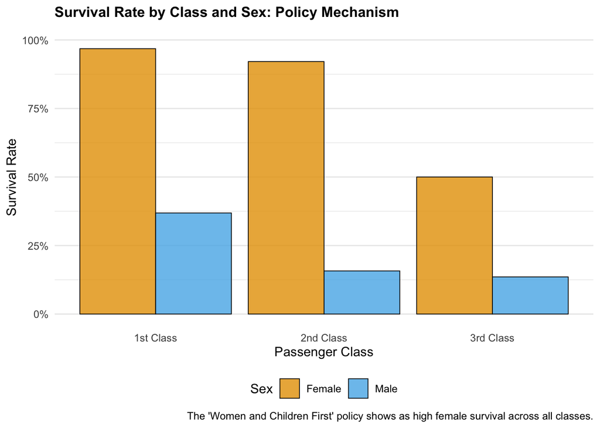

```r
# Create visualization of policy effect
viz_policy <- titanic %>%
  group_by(pclass_label, sex_label) %>%
  summarise(
    n = n(),
    survival_rate = mean(Survived),
    .groups = 'drop'
  ) %>%
  ggplot(aes(x = pclass_label, y = survival_rate, fill = sex_label)) +
  geom_col(position = "dodge", alpha = 0.8, color = "black", linewidth = 0.3) +
  scale_y_continuous(labels = scales::percent_format(accuracy = 1), limits = c(0, 1)) +
  scale_fill_manual(values = c("Female" = "#E69F00", "Male" = "#56B4E9")) +
  labs(
    title = "Survival Rate by Class and Sex: Policy Mechanism",
    x = "Passenger Class",
    y = "Survival Rate",
    fill = "Sex",
    caption = "The 'Women and Children First' policy shows as high female survival across all classes."
  ) +
  theme_minimal() +
  theme(
    legend.position = "bottom",
    plot.title = element_text(face = "bold", size = 12),
    panel.grid.major.x = element_blank()
  )

print(viz_policy)
```

## Cabin Information by Class and Survival

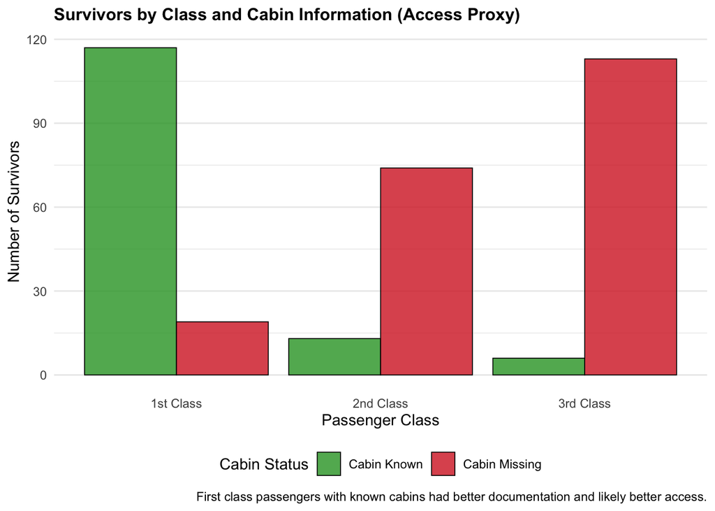

```r
# Visualize access difference: cabin information
cabin_data <- titanic %>%
  group_by(pclass_label, cabin_missing, Survived) %>%
  tally() %>%
  group_by(pclass_label, cabin_missing) %>%
  mutate(pct = 100 * n / sum(n)) %>%
  filter(Survived == 1)

viz_cabin <- cabin_data %>%
  ggplot(aes(x = pclass_label, y = n, fill = cabin_missing)) +
  geom_col(position = "dodge", alpha = 0.8, color = "black", linewidth = 0.3) +
  scale_fill_manual(values = c("FALSE" = "#2CA02C", "TRUE" = "#D62728"),
                    labels = c("FALSE" = "Cabin Known", "TRUE" = "Cabin Missing")) +
  labs(
    title = "Survivors by Class and Cabin Information (Access Proxy)",
    x = "Passenger Class",
    y = "Number of Survivors",
    fill = "Cabin Status",
    caption = "First class passengers with known cabins had better documentation and likely better access."
  ) +
  theme_minimal() +
  theme(
    legend.position = "bottom",
    plot.title = element_text(face = "bold", size = 12),
    panel.grid.major.x = element_blank()
  )

print(viz_cabin)
```

This visualization shows the access mechanism: first class passengers had documented cabin information at a much higher rate than third class. Among 216 first class passengers, 176 had known cabins, versus 12 of 491 third class passengers. Known cabin location likely facilitated evacuation by enabling crew to locate and direct passengers to lifeboats.

## Fare Distribution by Class

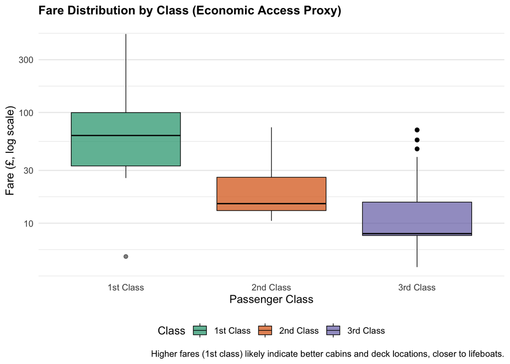

```r
# Visualize economic access
viz_fare <- titanic %>%
  filter(!is.na(Fare)) %>%
  ggplot(aes(x = pclass_label, y = Fare, fill = pclass_label)) +
  geom_boxplot(alpha = 0.7, outlier.alpha = 0.5, color = "black", linewidth = 0.3) +
  scale_y_log10() +
  scale_fill_manual(values = c("1st Class" = "#1B9E77", "2nd Class" = "#D95F02", "3rd Class" = "#7570B3")) +
  labs(
    title = "Fare Distribution by Class (Economic Access Proxy)",
    x = "Passenger Class",
    y = "Fare (£, log scale)",
    fill = "Class",
    caption = "Higher fares (1st class) likely indicate better cabins and deck locations, closer to lifeboats."
  ) +
  theme_minimal() +
  theme(
    legend.position = "bottom",
    plot.title = element_text(face = "bold", size = 12),
    panel.grid.major.x = element_blank()
  )

print(viz_fare)
```

Fare paid is a strong proxy for economic resources and accommodation quality. The median fare for first class (£60) is substantially higher than second (£14) and third class (£8). Higher fares presumptively purchased cabins in more accessible locations on the ship.

# Summary and Methodological Implications

## Key Findings for Decomposition

This analysis proposes a framework to address the research question: “How much of the class–survival gap is explained by access/constraints rather than policy?”

The **unadjusted class effect** (Model 1) establishes the baseline gap: each class level reduces survival odds by 57.3%.

Adding **access proxies** like cabin information and fare (Model 3) reduces the class effect by 17.3%, suggesting this percentage reflects structural differences in cabin location and documented access.

## Limitations and Next Steps

1. **Cabin data sparsity**: With ~77% missing cabin information overall, our cabin-based proxies are limited. Future research could use historical ship diagrams to infer cabin locations from ticket numbers.
2. **Unmeasured mechanisms**: The unexplained portion of the class effect may reflect crew behavior, additional policy implementations, or factors not captured in available data.
3. **Causal interpretation**: These models are descriptive decompositions, not true causal mediation analyses. Proper causal inference would require additional assumptions or methods (e.g., natural experiments, instrumental variables).
4. **Family dynamics**: Family size shows complex relationships with survival; future analysis could model family-level evacuation patterns using ticket groupings.